# E-news Express

## Background:

E-news Express, an online news portal aims to expand its business by acquiring new subscribers. The company plans to analyze the interests of its web users and wants to determine whether a new feature will be effective or not.

The design team of the company has created a new landing page.

Randomly selected 100 users are divided equally into two groups. The old landing page is served to the first group (control group) and the new landing page is served to the second group (treatment group). Various data about the customers in both groups have been collected.

## Objective:

- Through statistical analysis find if the new landing page is more effective to gather new subscribers.

## Questions:

- 1. Do the users spend more time on the new landing page than the old landing page?
- 1. Is the conversion rate for the new page greater than the conversion rate for the old page?
- 1. Does the converted status depend on the preferred language?
- 1. Is the mean time spent on the new page same for the different language users?

## Data Description:

1. user_id - This represents the user ID of the person visiting the website.
2. group - This represents whether the user belongs to the first group (control) or the second group (treatment).
3. landing_page - This represents whether the landing page is new or old.
4. time_spent_on_the_page - This represents the time (in minutes) spent by the user on the landing page.
5. converted - This represents whether the user gets converted to a subscriber of the news portal or not.
6. language_preferred - This represents the language chosen by the user to view the landing page.
- Exploratory Data Analysis
- Univariate Data Analysis
- Bivariate Analysis
- Question 1. Do the users spend more time on the new landing page than the old landing page?
- Question 2: Is the conversion rate for the new page greater than the conversion rate for the old page?
- Question 3 - Does the converted status depend on the preferred language?
- Question 4 -Is the mean time spent on the new page same for the different language users?

### Import needed python libraries - pandas, numpy, seaborn, matplotlib.pyplot

```python
# Libraries to help with reading and manipulating data
import pandas as pd
import numpy as np
import matplotlib.pyplot as plt

# Libraries to help with data visualization
import seaborn as sns
import matplotlib.pyplot as plt
%matplotlib inline
sns.set(style="darkgrid")

# Library to generates profile reports from a pandas DataFrame
import pandas_profiling

#supress warnings on depreceated features
import warnings
warnings.filterwarnings("ignore")
```

### Read the dataset

```python
data = pd.read_csv('abtest.csv')
```

```python
# copyy original data to another variable to avoid accidental changes to original data
df = data.copy()
```

#### View the head of data

```python
# looking at first 10 observations
df.head(10)
```

|  | user_id | group | landing_page | time_spent_on_the_page | converted | language_preferred |
| --- | --- | --- | --- | --- | --- | --- |
| 0 | 546592 | control | old | 3.48 | no | Spanish |
| 1 | 546468 | treatment | new | 7.13 | yes | English |
| 2 | 546462 | treatment | new | 4.40 | no | Spanish |
| 3 | 546567 | control | old | 3.02 | no | French |
| 4 | 546459 | treatment | new | 4.75 | yes | Spanish |
| 5 | 546558 | control | old | 5.28 | yes | English |
| 6 | 546448 | treatment | new | 5.25 | yes | French |
| 7 | 546581 | control | old | 6.53 | yes | Spanish |
| 8 | 546461 | treatment | new | 10.71 | yes | French |
| 9 | 546548 | control | old | 2.08 | no | English |

#### View the tail of data

```python
# looking at last 10 observations
df.tail(10)
```

|  | user_id | group | landing_page | time_spent_on_the_page | converted | language_preferred |
| --- | --- | --- | --- | --- | --- | --- |
| 90 | 546477 | treatment | new | 5.40 | no | French |
| 91 | 546451 | treatment | new | 8.47 | yes | English |
| 92 | 546566 | control | old | 8.35 | no | French |
| 93 | 546474 | treatment | new | 4.94 | no | French |
| 94 | 546550 | control | old | 3.05 | no | English |
| 95 | 546446 | treatment | new | 5.15 | no | Spanish |
| 96 | 546544 | control | old | 6.52 | yes | English |
| 97 | 546472 | treatment | new | 7.07 | yes | Spanish |
| 98 | 546481 | treatment | new | 6.20 | yes | Spanish |
| 99 | 546483 | treatment | new | 5.86 | yes | English |

#### Check the shape of the dataset

```python
df.shape
```

```
(100, 6)
```

- The dataset has 100 rows and 6 columns.

#### Check for any missing data

```python
#check for missing data
df.isna().sum()
```

```
user_id                   0
group                     0
landing_page              0
time_spent_on_the_page    0
converted                 0
language_preferred        0
dtype: int64
```

- There are **no** missing data, all the data rows have value for all the columns

### Check the info of the data

```python
df.info()
```

```
<class 'pandas.core.frame.DataFrame'>
RangeIndex: 100 entries, 0 to 99
Data columns (total 6 columns):
 #   Column                  Non-Null Count  Dtype
---  ------                  --------------  -----
 0   user_id                 100 non-null    int64
 1   group                   100 non-null    object
 2   landing_page            100 non-null    object
 3   time_spent_on_the_page  100 non-null    float64
 4   converted               100 non-null    object
 5   language_preferred      100 non-null    object
dtypes: float64(1), int64(1), object(4)
memory usage: 4.8+ KB
```

### Data Preprocessing

```python
# Corrrect the datatypes for group, landing_page, time_spent_on_the_page, converted and language_preferred
#  group, landing_page, time_spent_on_the_page, converted and language should be converted to categorical type
df['group'] = df.group.astype('category')
df['landing_page'] = df.landing_page.astype('category')
df['converted'] = df.converted.astype('category')
df['language_preferred'] = df.language_preferred.astype('category')
```

```python
df.info()
```

```
<class 'pandas.core.frame.DataFrame'>
RangeIndex: 100 entries, 0 to 99
Data columns (total 6 columns):
 #   Column                  Non-Null Count  Dtype
---  ------                  --------------  -----
 0   user_id                 100 non-null    int64
 1   group                   100 non-null    category
 2   landing_page            100 non-null    category
 3   time_spent_on_the_page  100 non-null    float64
 4   converted               100 non-null    category
 5   language_preferred      100 non-null    category
dtypes: category(4), float64(1), int64(1)
memory usage: 2.6 KB
```

### Summary of the data

```python
df.describe().T
```

|  | count | mean | std | min | 25% | 50% | 75% | max |
| --- | --- | --- | --- | --- | --- | --- | --- | --- |
| user_id | 100.0 | 546517.0000 | 52.295779 | 546443.00 | 546467.75 | 546492.500 | 546567.2500 | 546592.00 |
| time_spent_on_the_page | 100.0 | 5.3778 | 2.378166 | 0.19 | 3.88 | 5.415 | 7.0225 | 10.71 |

#### Check for Unique values of user_id

```python
# get unique values
#convert the series to a list and find the len of the list
len(df['user_id'].unique().tolist())
```

```
100
```

- All the users are unique
- For this analysis user_id does not play any significant role

#### Check the 5 point summary for time_spent_on_the_page

```python
time_on_page = df['time_spent_on_the_page']
time_on_page.describe()
```

```
count    100.000000
mean       5.377800
std        2.378166
min        0.190000
25%        3.880000
50%        5.415000
75%        7.022500
max       10.710000
Name: time_spent_on_the_page, dtype: float64
```

**Observations**

- Mean time_spent_on_the_page is 5.38 minutes
- Most users spend about 3.8 to 7 minutes

#### Let's check the count of each unique category in each of the categorical variables.

```python
#Make a list of all catrgorical columns
cat_cols=['group', 'landing_page', 'converted', 'language_preferred']

#Printing number of count of each unique value in each column
for column in cat_cols:
    print(df[column].value_counts())
    print('-'*30)
```

```
control      50
treatment    50
Name: group, dtype: int64
------------------------------
new    50
old    50
Name: landing_page, dtype: int64
------------------------------
yes    54
no     46
Name: converted, dtype: int64
------------------------------
French     34
Spanish    34
English    32
Name: language_preferred, dtype: int64
------------------------------
```

**Observations**

**group**

```
-   The data is equally divided btween two groups control group and treatment group.
```

**landing_page**

```
-   Here again the observations areequally divided btween two landing page new and old.
```

**converted**

```
-   Data set has slightly more users converted to a subscriber
```

**language_preferred**

```
-   Observation for each language is almost equal and exceeds the n=30 for central limit theorem
```

- The old landing page is served to the first group (control group) and the new landing page is served to the second group (treatment group).

# **Exploratory Data Analysis**

```python
# import the library for labelling
import matplotlib.patheffects as path_effects

def add_median_labels(ax):
    lines = ax.get_lines()
    # determine number of lines per box (this varies with/without fliers)
    boxes = [c for c in ax.get_children() if type(c).__name__ == 'PathPatch']
    lines_per_box = int(len(lines) / len(boxes))
    # iterate over median lines
    for median in lines[4:len(lines):lines_per_box]:
        # display median value at center of median line
        x, y = (data.mean() for data in median.get_data())
        # choose value depending on horizontal or vertical plot orientation
        value = x if (median.get_xdata()[1]-median.get_xdata()[0]) == 0 else y
        text = ax.text(x, y, f'{value:.1f}', ha='center', va='center',
                       fontweight='bold', color='white', bbox=dict(facecolor='black'),size=15)
        # create median-colored border around white text for contrast
        text.set_path_effects([
            path_effects.Stroke(linewidth=3, foreground=median.get_color()),
            path_effects.Normal(),
        ])
```

```python
def box_and_histogram(column,  figsize=(10,10), bins = None):
    """ Boxplot and histogram together, with median labels on boxplot
    df_series: dataframe column
    figsize: size of fig (default (9,8))
    bins: number of bins (default None / auto)
    color of mean is green and median is black
    """
    f2, (ax_box2, ax_hist2) = plt.subplots(nrows = 2, # Number of rows of the subplot grid= 2
                                           sharex = True, # x-axis will be shared among all subplots
                                           gridspec_kw = {"height_ratios": (.25, .75)},
                                           figsize = figsize
                                            ) # creating the 2 subplots
    box_plot = sns.boxplot(column, ax=ax_box2,showmeans=True, color='red')
    add_median_labels(box_plot.axes)


    sns.distplot(column, kde=F, bins=bins) if bins else sns.distplot(column, kde=True, ) # For histogram
    ax_hist2.axvline(np.mean(column), color='g', linestyle='--') # Add mean to the histogram
    ax_hist2.axvline(np.median(column), color='black', linestyle='-') # Add median to the histogram
```

# **Univariate Data Analysis**

# Observations from time_spent_on_the_page

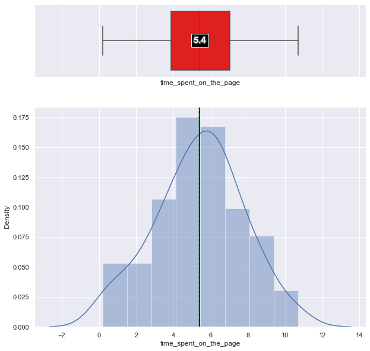

```python
box_and_histogram(df['time_spent_on_the_page']); # Box and histplot for time_spent_on_the_page
```

**Observations**

- The data follows almost normal distribution
- The mean is 5.38

```python
# Function to create barplots that indicate percentage for each category.
def barplot_with_percent(plot, df_series):
    '''
    plot
    df_series: dataframe column
    '''

    total = len(df_series) # length of the column
    for p in ax.patches:
        percentage = '{:.1f}%'.format(100 * p.get_height()/total) # percentage of each class of the category
        x = p.get_x() + p.get_width() / 2 - 0.05 # width of the plot
        y = p.get_y() + p.get_height()           # hieght of the plot
        ax.annotate(percentage, (x, y), size = 12) # annotate the percantage
```

## Observations on group

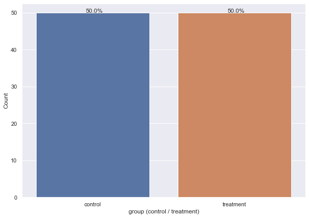

```python
plt.figure(figsize=(10,7))  # set plot size
ax = sns.countplot(df['group'])  # seaborn count plot
plt.xlabel('group (control / treatment)')  # Add label
plt.ylabel('Count')
barplot_with_percent(ax,df['group'])  # box lot with percentage
```

- 100 users are divided equally into two groups

## Observations on landing_page

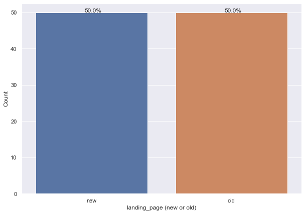

```python
plt.figure(figsize=(10,7))  # set plot size
ax = sns.countplot(df['landing_page'])  # seaborn count plot
plt.xlabel('landing_page (new or old)')  # Add label
plt.ylabel('Count')
barplot_with_percent(ax,df['landing_page'])  # box lot with percentage
```

- 100 users are divided equally and served old and new landing page
- The old landing page is served to the first group (control group) and the new landing page is served to the second group (treatment group).

## Observations on converted

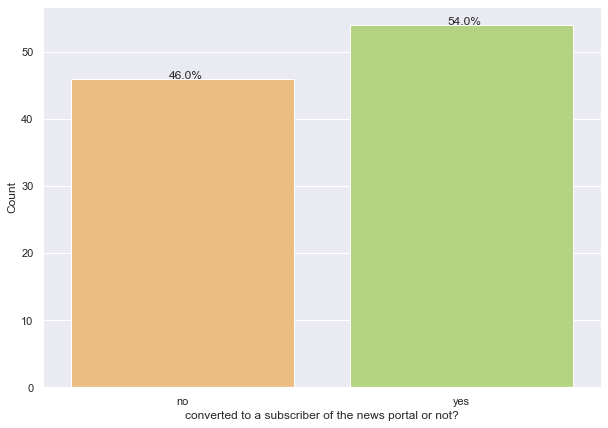

```python
plt.figure(figsize=(10,7))  # set plot size
ax = sns.countplot(df['converted'], palette ='RdYlGn')  # seaborn count plot
plt.xlabel('converted to a subscriber of the news portal or not?')  # Add label
plt.ylabel('Count')
barplot_with_percent(ax,df['converted'])  # box lot with percentage
```

- Of the 100 users, users who got converted to subscribers form a larger percentage of about 54%

## Observations on language_preferred

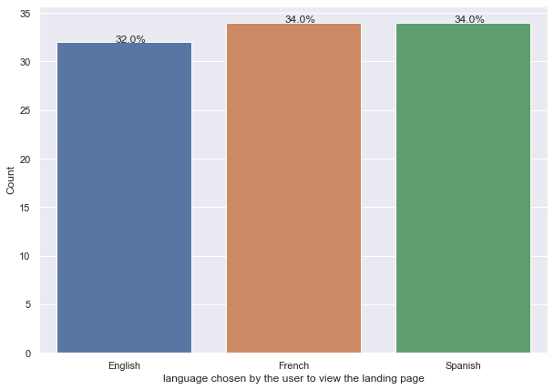

```python
plt.figure(figsize=(10,7))  # set plot size
ax = sns.countplot(df['language_preferred'])  # seaborn count plot
plt.xlabel('language chosen by the user to view the landing page')  # Add label
plt.ylabel('Count')
barplot_with_percent(ax,df['language_preferred'])  # box lot with percentage
```

- The data distribution between preferred languages of English, French and Spanish is almost uniform.

# **Bivariate Analysis**

### landing_page type Vs converted to subscriber status

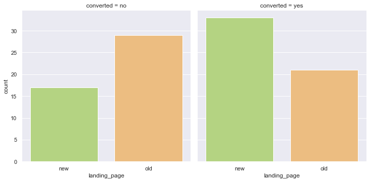

```python
sns.catplot(x='landing_page',
             col='converted',
             data=df,
             col_wrap=3,
             kind="count",
             palette ='RdYlGn_r');
```

- The new landing page has more users who have been converted to subscribers.

### Landing_page type Vs Group

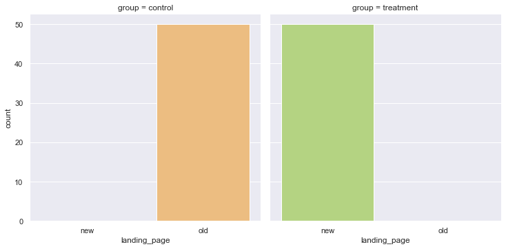

```python
sns.set(rc={'figure.figsize':(13,8)})
sns.catplot(x='landing_page',
             col='group',
             data=df,
             col_wrap=3,
             kind="count",
             palette ='RdYlGn_r');
```

- The old landing page is served to the first group (control group) and the new landing page is served to the second group (treatment group).
- The data is equally divided into two groups.

### Landing_page type Vs Converted Vs language preferred

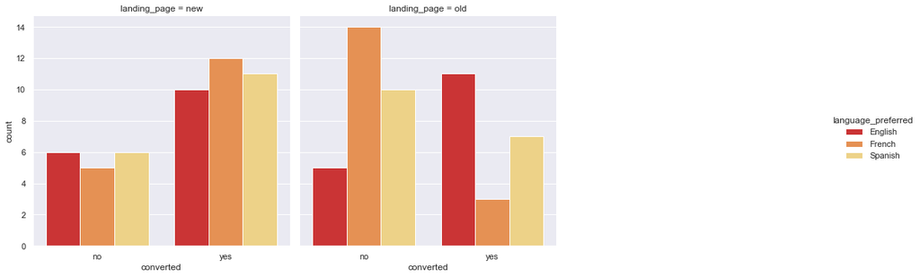

```python
sns.set(rc={'figure.figsize':(13,8)});
sns.catplot(x='converted',
             col='landing_page',
             data=df,
             hue='language_preferred',
             col_wrap=3,
             kind="count",
             palette ='YlOrRd_r'
           );
```

- The new landing page has more a uniform distribution compared to old landing page.

### Landing_page type Vs Group type Vs language preferred

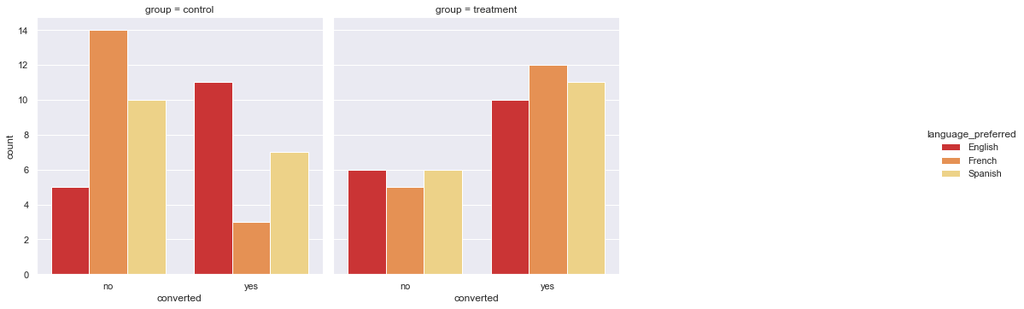

```python
sns.catplot(x='converted',
             col='group',
             data=df,
             hue='language_preferred',
             col_wrap=3,
             kind="count",
             palette ='YlOrRd_r'
           );
```

- The group(treatment) has more a uniform distribution compared to other group (control).

### converted type Vs time_spent_on_the_page Vs language preferred

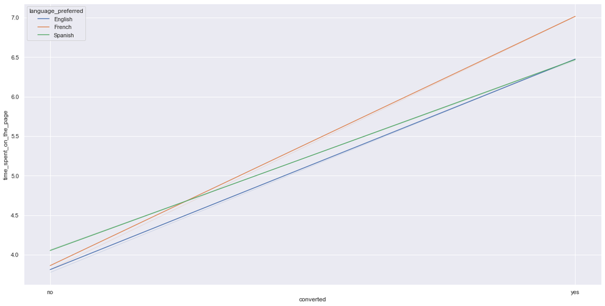

```python
plt.figure(figsize=(20,10))
sns.lineplot(x="converted", y="time_spent_on_the_page",hue='language_preferred', data=df,ci=0,color="RED")
plt.ylabel('time_spent_on_the_page')
plt.xlabel('converted')
plt.show()
```

- Subscribers are more likely to spend more time on the web page.

# **Question 1. Do the users spend more time on the new landing page than the old landing page?**

```python
#get the rows with specific values into seperate data frames
new_landing_page = df[df.landing_page  == 'new']
old_landing_page = df[df.landing_page  == 'old']
# rename the columns
new_landing_page = new_landing_page.rename( columns = {'time_spent_on_the_page': 'time_spent_on_the_new_page'})
old_landing_page = old_landing_page.rename( columns = {'time_spent_on_the_page': 'time_spent_on_the_old_page'})
```

```python
new_landing_page.head(10)
```

|  | user_id | group | landing_page | time_spent_on_the_new_page | converted | language_preferred |
| --- | --- | --- | --- | --- | --- | --- |
| 1 | 546468 | treatment | new | 7.13 | yes | English |
| 2 | 546462 | treatment | new | 4.40 | no | Spanish |
| 4 | 546459 | treatment | new | 4.75 | yes | Spanish |
| 6 | 546448 | treatment | new | 5.25 | yes | French |
| 8 | 546461 | treatment | new | 10.71 | yes | French |
| 12 | 546491 | treatment | new | 5.86 | yes | Spanish |
| 13 | 546478 | treatment | new | 6.03 | yes | French |
| 15 | 546466 | treatment | new | 6.27 | yes | Spanish |
| 16 | 546443 | treatment | new | 8.73 | no | English |
| 22 | 546450 | treatment | new | 3.65 | no | English |

```python
new_landing_page.shape
```

```
(50, 6)
```

```python
# find the mean and standard deviation of the time spent on new landing page and old landing page
print('The mean time spent on new landing_page {}'.format(round(new_landing_page.time_spent_on_the_new_page.mean(),2)))
print('The std deviation time spent on new landing_page {}'.format(round(new_landing_page.time_spent_on_the_new_page.std(),2)))
print("--"*15)
print('The mean time spent on old landing_page {}'.format(round(old_landing_page.time_spent_on_the_old_page.mean(),2)))
print('The std deviation time spent on old landing_page {}'.format(round(old_landing_page.time_spent_on_the_old_page.std(),2)))
```

```
The mean time spent on new landing_page 6.22
The std deviation time spent on new landing_page 1.82
------------------------------
The mean time spent on old landing_page 4.53
The std deviation time spent on old landing_page 2.58
```

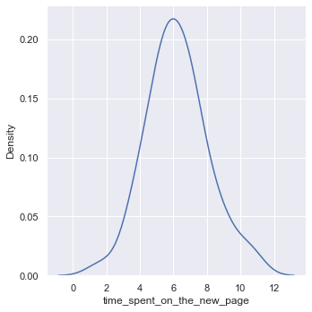

```python
sns.displot(new_landing_page['time_spent_on_the_new_page'],kind="kde");
```

- As we can see in the above plot, the shape is close to normal, for the time spent on the new page

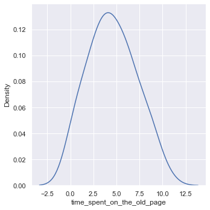

```python
sns.displot(old_landing_page['time_spent_on_the_old_page'],kind="kde");
```

- As we can see in the above plot, the shape is close to normal, for time spent on old page

### Step 1: Define null and alternative hypotheses

### Let's write the null and alternative hypothesis

Let $\mu_1, \mu_2$ be the mean time_spent_on **old** and **new**, **control** and **treatment** groups respectively.

We will test the null hypothesis

> $H_0:\mu_1=\mu_2$
- mean time_spent_on old and new landing page are equal

against the alternate hypothesis

> $H_a:\mu_1<\mu_2$
- mean time_spent_on new landing page is greater than the old landing page

### Step 2: Select Appropriate test

- As the population mean is not known , we use the T test.
- As the two standard deviations are not equal , we use the **Two Independent Sample T-test for Equality of Means - Unequal Std Dev**.

### Let's test whether the T-test assumptions are satisfied or not

- Continuous data - Yes, the time spent is measured on a continuous scale.
- Independent populations - As we are taking random samples for two different groups, the two samples are from two independent populations.
- Unequal population standard deviations - As the sample standard deviations are different, the population standard deviations may be assumed to be different.
- Random sampling from the population - Yes, we are informed that the collected sample a simple random sample.

### Step 3: Decide the significance level

Here, we select α = 0.05.

### Step 5: Calculate the p-value

```python
#import the required functions
from scipy.stats import ttest_ind

# find the p-value
test_stat, p_value = ttest_ind(old_landing_page['time_spent_on_the_old_page'], new_landing_page['time_spent_on_the_new_page'].dropna(), equal_var = False, alternative = 'less')
print('The p-value is ', p_value)
```

```
The p-value is  0.0001392381225166549
```

### Insight

As the p-value (~0.00013) is less than the level of significance (.05), we can reject the null hypothesis. Hence, we do have enough evidence to support the claim that

- Users spend more time on the new landing page than the old landing page

### Conclusion

**Do the users spend more time on the new landing page than the old landing page?**

> **Users spend more time on the new landing page than the old landing page**.

## Visual representation of the conclusion for Question 1

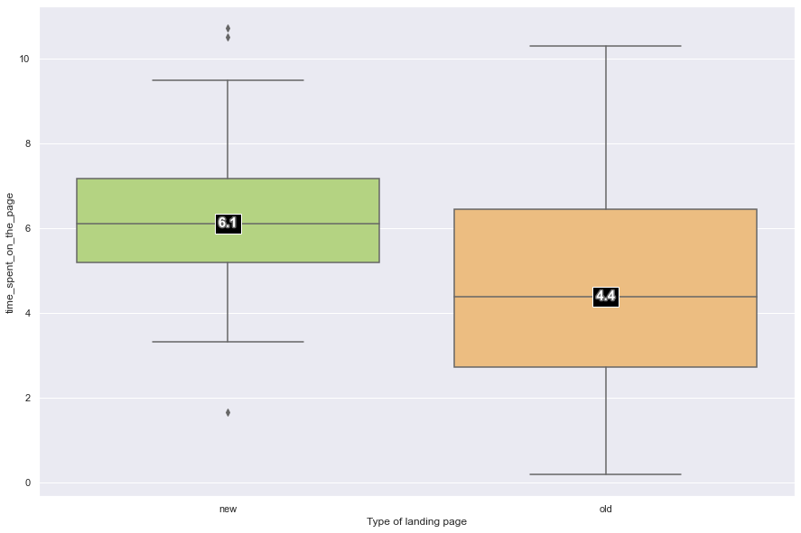

```python
plt.figure(figsize=(15,10))  # To resize the plot
box_plot = sns.boxplot(df['landing_page'],df['time_spent_on_the_page'],showmeans=True,palette ='RdYlGn_r')
add_median_labels(box_plot.axes)
plt.ylabel('time_spent_on_the_page')
plt.xlabel('Type of landing page')
plt.show()
```

### Conclusion from Visual representation for question 1

- **Users spend more time on the new landing page than the old landing page**.
- There some outliers on the usage for the new landing page

# **Question 2: Is the conversion rate for the new page greater than the conversion rate for the old page?**

### Step 1: Define null and alternative hypotheses

### Let's write the null and alternative hypothesis

Let $p_1,p_2$ be the proportions of conversion rate for old and new landing page respectively.

The proportions for old and new landing page are equal

> $H_0:p_1 =p_2$

against the alternate hypothesis The proportions for new landing page is greater than old landing page

> $H_a:p_1 \lt p_2$

### Step 2: Select Appropriate test

- Hypotheses are concerned with proportions.
- A test of proportions can be used to analyse the hypotheses and draw a conclusion.
- We shall use a **Proportions Z test** for this problem.

#### Let get a view of the data

```python
# number of user gets converted to a subscriber from new page
users_to_Subscriber_from_new_page = df[df['landing_page']=='new'].converted.value_counts()['yes']
# number of user gets converted to a subscriber from old page
users_to_Subscriber_from_old_page = df[df['landing_page']=='old'].converted.value_counts()['yes']

print('The numbers of new page user converted  and  old page user converted are {0} and {1} respectively'.
      format(users_to_Subscriber_from_new_page, users_to_Subscriber_from_old_page))

# number of user on new page
new_page_users = df.landing_page.value_counts()['new']

# number of user on old page
old_page_users = df.landing_page.value_counts()['old']

print('The total numbers of new_page_users and old_page_users are {0} and {1} respectively'.
      format(new_page_users, old_page_users))
```

```
The numbers of new page user converted  and  old page user converted are 33 and 21 respectively
The total numbers of new_page_users and old_page_users are 50 and 50 respectively
```

### Let's test whether the Z-test assumptions are satisfied or not

- Binomally distributed population - Yes, a user is either converted or not
- Random sampling from the population - Yes, we are informed that the collected sample is a simple random sample.
- Can the binomial distribution approximated to normal distribution - Yes.
- The standard thing is to check whether np and n(1-p) are greater than or equal to 10.
- Here, n and p refer to the sample size and sample proportion respectively.

  > $np_1 = 50\cdot \frac{33}{50} =33 \geq 10\\ n(1-p_1) = 50 \cdot \frac{50-33}{50} =17 \geq 10 \\ np_2 = 50\cdot \frac{21}{50} =21 \geq 10\\ n(1-p_2) = 50 \cdot \frac{50-21}{50} =29 \geq 10 $

**Proportions Z test** assumptions are satisfied for this problem.

### Step 3: Decide the significance level

- Here, we select α = 0.05.

### Step 4: Data Preparation

```python
print(f'Proportions of new_page user converted to subscribers and old_page user converted to subscribers  \
are {round(33/50,2)}, {round(21/50,2)} respectively')
```

```
Proportions of new_page user converted to subscribers and old_page user converted to subscribers  are 0.66, 0.42 respectively
```

- The proportions in the sample are different. Let's conduct the test to see if this difference is significant.

```python
# import the required fuction
from statsmodels.stats.proportion import proportions_ztest

# set the counts of defective items
converted_count = np.array([33, 21])

# set the sample sizes
nobs = np.array([50, 50])

# find the p-value
test_stat, p_value = proportions_ztest(converted_count, nobs)
print('The p-value is ' + str(p_value))
print('The p-value rounded to two decimals {} ' .format(round(p_value,2)))
```

```
The p-value is 0.016052616408112556
The p-value rounded to two decimals 0.02
```

### Insight

As the p-value is less than the significance level 0.05, we can reject the null hypothesis. Thus, the proportions of conversion rate for new and old landing page are not equal.

### Conclusion

**Is the conversion rate for the new page greater than the conversion rate for the old page**

> **The conversion rate for the new page is greater than the conversion rate for the old page**.

### Visual representation of the conclusion for Question 2

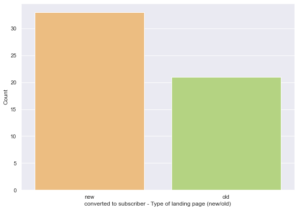

```python
plt.figure(figsize=(10,7))  # set plot size
sns.countplot(df.landing_page[df['converted'] == 'yes'], palette ='RdYlGn')  # seaborn count plot
plt.xlabel('converted to subscriber - Type of landing page (new/old)')  # Add label
plt.ylabel('Count')
```

### Conclusion from the Visual representation of Question 2

> **The conversion rate for the new page is greater than the conversion rate for the old page**.

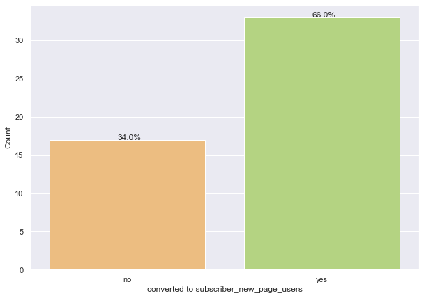

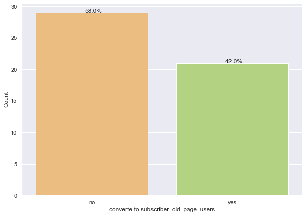

```python
plt.figure(figsize=(10,7))  # set plot size
ax = sns.countplot(new_landing_page['converted'], palette ='RdYlGn')  # seaborn count plot
plt.xlabel('converted to subscriber_new_page_users')  # Add label
plt.ylabel('Count')
barplot_with_percent(ax,new_landing_page['converted'])  # box lot with percentage

plt.figure(figsize=(10,7))  # set plot size
ax = sns.countplot(old_landing_page['converted'], palette ='RdYlGn')  # seaborn count plot
plt.xlabel('converte to subscriber_old_page_users')  # Add label
plt.ylabel('Count')
barplot_with_percent(ax,old_landing_page['converted'])  # box lot with percentage
```

### Conclusion Visual representation for question 2

> **The conversion rate for the new page is greater than the conversion rate for the old page**.

# **Question 3: Does the converted status depend on the preferred language?**

```python
# usecrosstab to get the contigency table
df_contg = pd.crosstab(df.converted,df.language_preferred)
df_contg
```

| language_preferred converted | English | French | Spanish |
| --- | --- | --- | --- |
| no | 11 | 19 | 16 |
| yes | 21 | 15 | 18 |

```python
#  use crosstab to get the contigency table with the total's
df_contg_total = pd.crosstab(df.converted,df.language_preferred,margins=True, margins_name = 'Total')
df_contg_total
```

| language_preferred converted | English | French | Spanish | Total |
| --- | --- | --- | --- | --- |
| no | 11 | 19 | 16 | 46 |
| yes | 21 | 15 | 18 | 54 |
| Total | 32 | 34 | 34 | 100 |

### Step 1: Define null and alternative hypotheses

### Let's write the null and alternative hypothesis

We will test the null hypothesis

> $H_0:$ Converted status is independent of preferred language.

against the alternate hypothesis

> $H_a:$ Converted status is dependent on preferred language.

### Step 2: Select Appropriate test

The formulated hypotheses can be tested using a Chi-square test of independence of attributes, concerning the two categorical variables, converted status and preferred language.

### Let's test whether the assumptions are satisfied or not

- Categorical variables - Yes
- Expected value of the number of sample observations in each level of the variable is at least 5
  - Yes, the number of observations in each level is greater than 5.
- Random sampling from the population - Yes, we are informed that the collected sample is a simple random sample.

#### - Chi-Square Test for Independence is appropriate test

### Step 3: Decide the significance level

- Here, we select α = 0.05.

### Step 4: Data Preparation

```python
# import the required function
from scipy.stats import chi2_contingency

# find the p-value
chi, p_value, dof, expected = chi2_contingency(df_contg)
print('The p-value is', p_value)
```

```
The p-value is 0.21298887487543447
```

### Visual representation of the conclusion for Question 3

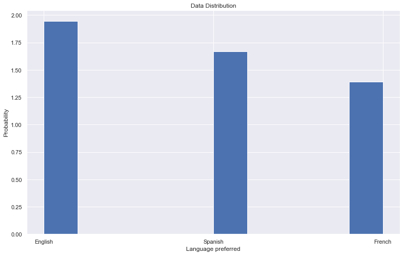

```python
# visualize the distribution of the time needed for bug fixing
plt.hist(df.language_preferred[df["converted"] == 'yes'], density=True)
plt.xlabel("Language preferred")
plt.ylabel("Probability")
plt.title("Data Distribution")
plt.show()
```

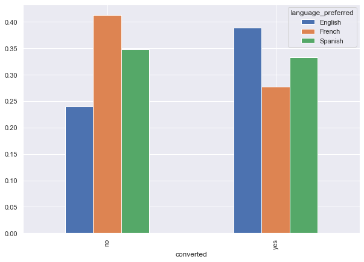

```python
pd.crosstab(df.converted, df.language_preferred, normalize='index').plot.bar(stacked=False,figsize=(10,7));
```

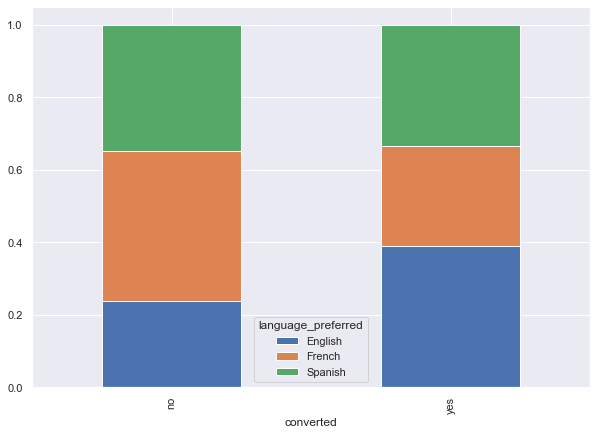

```python
pd.crosstab(df.converted, df.language_preferred, normalize='index').plot.bar(stacked=True,figsize=(10,7));
```

# **Question 4: Is the mean time spent on the new page same for the different language users?**

```python
# get the new landing page details
df_new_page = df[df['landing_page']== 'new']
```

```python
# get the levels of language_preferred
df_new_page['language_preferred'].value_counts()
```

```
French     17
Spanish    17
English    16
Name: language_preferred, dtype: int64
```

```python
df_new_page.head(5)
```

|  | user_id | group | landing_page | time_spent_on_the_page | converted | language_preferred |
| --- | --- | --- | --- | --- | --- | --- |
| 1 | 546468 | treatment | new | 7.13 | yes | English |
| 2 | 546462 | treatment | new | 4.40 | no | Spanish |
| 4 | 546459 | treatment | new | 4.75 | yes | Spanish |
| 6 | 546448 | treatment | new | 5.25 | yes | French |
| 8 | 546461 | treatment | new | 10.71 | yes | French |

### Step 1: Define null and alternative hypotheses

### Let's write the null and alternative hypothesis

Let $\mu_1, \mu_2, \mu_3$ be the means of time spent by English, French and Spanish users respectively.

We will test the null hypothesis

> $H_0: \mu_1 = \mu_2 = \mu_3$

against the alternative hypothesis

> $H_a: $ At least one mean time is different from the rest.

### Step 2: Select Appropriate test

One-way ANOVA Test is more appropriate

### Let's test whether the normality and eqality are satisfied or not

Now, the normality and equality of variance assumptions need to be checked.

- For testing of normality, Shapiro-Wilk’s test is applied to the response variable.
- For equality of variance, Levene test is applied to the response variable.

### Shapiro-Wilk’s test

We will test the null hypothesis

> $H_0:$ Time spent on the new page follows a normal distribution

against the alternative hypothesis

> $H_a:$ time spent on the new page does not follow a normal distribution

```python
# Assumption 1: Normality
# import the required function
from scipy import stats

# find the p-value
w, p_value = stats.shapiro(df_new_page['time_spent_on_the_page'])
print('The p-value is', p_value)
```

```
The p-value is 0.8040016293525696
```

Since p-value of the test is very large, we do not reject the null hypothesis that the response follows the normal distribution.

> **Time spent on the new page follows a normal distribution.**

### Levene’s test

We will test the null hypothesis

> $H_0$: All the variances are equal

against the alternative hypothesis

> $H_a$: At least one variance is different from the rest

```python
#Assumption 2: Homogeneity of Variance
#import the required function
from scipy.stats import levene
statistic, p_value = levene( df_new_page['time_spent_on_the_page'][df_new_page['language_preferred']=="English"],
                                   df_new_page['time_spent_on_the_page'][df_new_page['language_preferred']=="French"],
                                   df_new_page['time_spent_on_the_page'][df_new_page['language_preferred']=="Spanish"])
# find the p-value
print('The p-value is', p_value)
```

```
The p-value is 0.46711357711340173
```

Since the p-value is large, we do not reject the null hypothesis.

> **All the variances are equal.**

### Let's test whether the assumptions are satisfied or not

- The populations are normally distributed - Yes, the normality assumption is verified using the Shapiro-Wilk’s test.
- Samples are independent simple random samples - Yes, we are informed that the collected sample is a simple random sample.
- Population variances are equal - Yes, the homogeneity of variance assumption is verified using the Levene's test.

```python
#import the required function
from scipy.stats import f_oneway

# perform one-way anova test
test_stat, p_value = f_oneway(df_new_page.loc[df_new_page['language_preferred'] == 'English', 'time_spent_on_the_page'],
                              df_new_page.loc[df_new_page['language_preferred'] == 'French', 'time_spent_on_the_page'],
                              df_new_page.loc[df_new_page['language_preferred'] == 'Spanish', 'time_spent_on_the_page'])
print('The p-value is ' + str(p_value))
```

```
The p-value is 0.43204138694325955
```

### Conclusion

**Is the mean time spent on the new page same for the different language users?**

> **Yes, the mean time spent on the new page is same for the different language.**

### Visual representation of the conclusion for Question 4

```python
# mean of carbon emission at different levels of the fuel_type factor
print(df_new_page.groupby("language_preferred")["time_spent_on_the_page"].mean())
```

```
language_preferred
English    6.663750
French     6.196471
Spanish    5.835294
Name: time_spent_on_the_page, dtype: float64
```

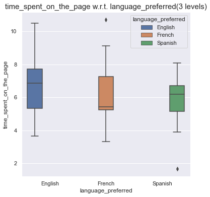

```python
# draw the boxplot for visualization
fig, ax = plt.subplots(figsize = (6,6))
a = sns.boxplot(x= "language_preferred", y = 'time_spent_on_the_page' , data = df_new_page, hue = 'language_preferred')
a.set_title("time_spent_on_the_page w.r.t. language_preferred(3 levels)", fontsize=15)
plt.show()
```

### Conclusion Visual representation for question 4

> **The mean time spent on the new page is same for the different languages**

### Pandas Profiling

```python
from pandas_profiling import ProfileReport
# Use the original dataframe, so that original features are considered
prof = ProfileReport(data)
# to view report created by pandas profile
prof
```

[interactive chart not shown]

### Observations from pandas profiling

**group** - The data is equally divided btween two groups control group and treatment group.

**landing_page** - Here again the observations areequally divided btween two landing page new and old.

**converted** - Data set has slightly more users converted to a subscriber

**language_preferred** - Observation for each language is almost equal and exceeds the n=30 for central limit theorem

- The old landing page is served to the first group (control group) and the new landing page is served to the second group (treatment group).

## Conclusion and Recommendations

### Conclusion

Dataset of 100 observation was analyzed. This data contained the usage characteristics of two groups. The old landing page is served to the first group (control group) and the new landing page is served to the second group (treatment group).

The key feature will be landing page type and time spent on the page . Also related is preferred language.

### Recommendation to business

1. **The new landing page is more successful in converting users to subscribers.**
2. **Users spend more time on the new landing page, irrespective of the preferred language.**